# Strategies to prevent overfitting in neural networks

```python
%matplotlib inline

import numpy as np
import pandas as pd
import tensorflow as tf

from sklearn.model_selection import train_test_split
from sklearn.metrics import accuracy_score
from sklearn.metrics import confusion_matrix

from tensorflow.keras import regularizers
from tensorflow.keras.preprocessing.text import Tokenizer
from tensorflow.keras.preprocessing.sequence import pad_sequences
from tensorflow.keras.layers import Embedding, Dense, GlobalMaxPooling1D, Dropout
from tensorflow.keras.models import Sequential
from tensorflow.keras import regularizers
from tensorflow.keras.callbacks import EarlyStopping

try:
    tf.set_random_seed(1337)                    # set the random seed for reproducibility
except:
    tf.random.set_seed(1337)                     # NOTE: Newer version of tensorflow uses tf.random.set_seed
np.random.seed(1337)                         #       instead of tf.set_random_seed
```

## Introduction (5 min)

**Business Context.** You are a data scientist working for a machine learning consultancy. One of your clients wants to be able to classify text reviews automatically by the likely rating (on a 1 - 5 scale) that that person would give. However, they do not have sufficient data they generated on their own to do this, so you need to use an external, rich dataset as a basis on which to build your model and then translate it over.

**Business Problem.** Your task is to **build a neural networks-based model for classifying text reviews into likely ratings (on a 1 - 5 scale)**.

**Analytical Context.** We'll use the Amazon review dataset again and try to classify reviews into star ratings automatically. Instead of just positive and negative, we'll take on the harder challenge of predicting the *exact* star rating. The lowest score is 1 and the highest is 5.

Instead of trying to optimize by pre-processing the text, we'll do very basic tokenization and experiment with different neural network models, architectures, and hyperparameters to optimize the results. You'll start by building a simple dense neural network and try to get it to perform better using various techniques. Then you'll evaluate the results and diagnose where it tends to perform more poorly.

## Setting up and preparing the data

We'll mainly be using the `keras` module from TensorFlow, but we'll also use `pandas` to read the CSV file and `sklearn` for some helper functions. We'll be using only the "Text" and "Score" columns in the `Reviews.csv` file:

```python
amazon_reviews = pd.read_csv('Reviews.csv', nrows=262084)
amazon_reviews.head(5)
```

|  | Id | ProductId | UserId | ProfileName | HelpfulnessNumerator | HelpfulnessDenominator | Score | Time | Summary | Text |
| --- | --- | --- | --- | --- | --- | --- | --- | --- | --- | --- |
| 0 | 1 | B001E4KFG0 | A3SGXH7AUHU8GW | delmartian | 1 | 1 | 5 | 1303862400 | Good Quality Dog Food | I have bought several of the Vitality canned d... |
| 1 | 2 | B00813GRG4 | A1D87F6ZCVE5NK | dll pa | 0 | 0 | 1 | 1346976000 | Not as Advertised | Product arrived labeled as Jumbo Salted Peanut... |
| 2 | 3 | B000LQOCH0 | ABXLMWJIXXAIN | Natalia Corres "Natalia Corres" | 1 | 1 | 4 | 1219017600 | "Delight" says it all | This is a confection that has been around a fe... |
| 3 | 4 | B000UA0QIQ | A395BORC6FGVXV | Karl | 3 | 3 | 2 | 1307923200 | Cough Medicine | If you are looking for the secret ingredient i... |
| 4 | 5 | B006K2ZZ7K | A1UQRSCLF8GW1T | Michael D. Bigham "M. Wassir" | 0 | 0 | 5 | 1350777600 | Great taffy | Great taffy at a great price. There was a wid... |

### Exercise 1: (15 min)

Combine the first 1,000 of each of the 1-, 2-, 3-, 4-, and 5-star reviews in `amazon_reviews` into a single DataFrame (so you should have 5,000 observations in total). Split this DataFrame into training and test sets, with 80% of the data for the training set.

**Hint:** `keras` will expected your labels to start with 0, and not 1, so make sure to adjust the labels accordingly.

**Answer.** One possible solution is shown below:

```python
star1 = amazon_reviews[amazon_reviews['Score'] == 1][["Text", "Score"]][:1000]
star2 = amazon_reviews[amazon_reviews['Score'] == 2][["Text", "Score"]][:1000]
star3 = amazon_reviews[amazon_reviews['Score'] == 3][["Text", "Score"]][:1000]
star4 = amazon_reviews[amazon_reviews['Score'] == 4][["Text", "Score"]][:1000]
star5 = amazon_reviews[amazon_reviews['Score'] == 5][["Text", "Score"]][:1000]

train, test = train_test_split(
    star1.append(star2).append(star3).append(star4).append(star5),
    test_size=0.2,
    random_state=1337
)

# note that we subtract 1 from each score as Keras will expect
# our labels to start at 0.
labels = np.array([score-1 for score in train['Score']])
y_true = [score-1 for score in test['Score']]
```

## Tokenizing our texts

Keras comes with its own functions to preprocess text, including a [tokenizer](https://www.tensorflow.org/api_docs/python/tf/keras/preprocessing/text/Tokenizer) (a mapping from each word in our corpus to a unique integer). Unlike the `CountVectorizer` from `sklearn`, which produces sparse matrices, `keras` often expects to work with sequences representing only the words that occur in a text. To prepare text before feeding it into a neural network, we usually:

1. Create a [tokenizer](https://www.tensorflow.org/api_docs/python/tf/keras/preprocessing/text/Tokenizer).
2. [Create sequences](https://www.tensorflow.org/api_docs/python/tf/keras/preprocessing/text/Tokenizer#texts_to_sequences) from our text (each text becomes a list of integers, based on the tokenizer mapping, instead of words)
3. [Pad or truncate](https://www.tensorflow.org/api_docs/python/tf/keras/preprocessing/sequence/pad_sequences) each sequence to a fixed length (very short texts get `0`s added to them, while very long ones are truncated).

The tokenizer has a configurable word cap, so it will only consider the $n$ most common words in the corpus, ignoring very rare words.

### Exercise 2: (30 min)

In this exercise, you will learn how to use the `tf.keras.preprocessing.text.Tokenizer` tool to carry out the preprocessing steps described above.

#### 2.1 (10 min)

Perform some exploratory analysis of the dataset to calculate the number of unique words in our corpus and the distribution of the number of words in each review of the training set. What is the 80th percentile of this distribution?

**Answer.** One possible solution is shown below:

```python
#Compute the number of unique words in our corpus:
num_words = len(set(' '.join(train['Text']).lower().split()))
print('The number of words appearing in our corpus is: ', num_words)

#Define a function that computes the length of a text
def word_count(text):
    return len(text.lower().split())

#Apply the word_count function to all the texts in our corpus:
text_lengths=train['Text'].apply(word_count)
print("The 80th percentile is: ", text_lengths.quantile(.8))

text_lengths.describe()
```

```
The number of words appearing in our corpus is:  27185
The 80th percentile is:  116.0
```

```
count    4000.000000
mean       83.108750
std        80.605107
min        12.000000
25%        36.000000
50%        62.000000
75%       103.000000
max      1751.000000
Name: Text, dtype: float64
```

#### 2.2 (5 min)

Given the results above, we create a tokenizer using only the top 20,000 most frequent words in our corpus (which corresponds to roughly 80% of the words):

```python
tokenizer = Tokenizer(num_words=20000) #We create the tokenizer using only top 20000 words
```

```python
tokenizer.fit_on_texts(train['Text'])  #Then, we create the text->indices mapping.
```

The above line has given several features and methods to our tokenizer. For instance, print the line `tokenizer.word_index` in a new cell - what do you see? Apply the `tokenizer.texts_to_sequences()` method on the list `['I just feel very very good']`. Apply the `tokenizer.sequences_to_texts()` method on the list `[[109, 19, 824, 76, 114, 6315, 1137, 8070]]`. What were your results?

**Answer.** We see that `tokenizer.word_index` is a dictionary that maps words present in our text corpus to indices. The methods `tokenizer.texts_to_sequences()` and `tokenizer.sequences_to_texts()` give us the following results:

```python
print(tokenizer.texts_to_sequences(['I just feel very very good']))
print(tokenizer.sequences_to_texts([[109, 19, 824, 76, 114, 6315, 1137, 8070]]))
```

```
[[2, 36, 351, 39, 39, 32]]
['did you miss your best data science professor']
```

#### 2.3 (5 min)

Use the tokenizer to transform the texts in our test and train data to sequences. Then, use the `pad_sequences` function to pad/truncate these sequences to length 116 (the 80th percentile of text lengths). Save the resulting arrays as `train_sequences` and `test_sequences`.

**Answer.** Shown below:

```python
train_sequences = tokenizer.texts_to_sequences(train['Text'])
train_sequences = pad_sequences(train_sequences, maxlen=116)

test_sequences = tokenizer.texts_to_sequences(test['Text'])
test_sequences = pad_sequences(test_sequences, maxlen=116)
```

## Building a basic neural network model

Now that we have preprocessed the text, let's create a basic neural network to train on our data. We'll use an embedding layer which performs [one-hot encoding](https://machinelearningmastery.com/why-one-hot-encode-data-in-machine-learning/) on our word sequences, two fully connected ("dense") layers, and an output layer with 5 neurons to represent the 5 possible star ratings.

Before we train a `keras` model, there is an additional `compile` step where we define what loss function and optimizer to use, and what metrics to output. Then we can train the model using the `fit` function. All of this is shown below.

```python
model = Sequential()
model.add(Embedding(20000, 128, input_length=116))
model.add(Dense(128, activation='relu'))
model.add(Dense(128, activation='relu'))
model.add(GlobalMaxPooling1D())
model.add(Dense(5, activation='sigmoid'))
model.compile(loss='sparse_categorical_crossentropy', optimizer='adam', metrics=['accuracy'])
```

```python
model.summary()
```

```
Model: "sequential"
_________________________________________________________________
Layer (type)                 Output Shape              Param #
=================================================================
embedding (Embedding)        (None, 116, 128)          2560000
_________________________________________________________________
dense (Dense)                (None, 116, 128)          16512
_________________________________________________________________
dense_1 (Dense)              (None, 116, 128)          16512
_________________________________________________________________
global_max_pooling1d (Global (None, 128)               0
_________________________________________________________________
dense_2 (Dense)              (None, 5)                 645
=================================================================
Total params: 2,593,669
Trainable params: 2,593,669
Non-trainable params: 0
_________________________________________________________________
```

```python
model.fit(train_sequences, labels, validation_split=0.2, epochs=10)
```

```
<tensorflow.python.keras.callbacks.History at 0x7f5606fbf160>
```

### Exercise 3: (10 min)

How well does this model perform? How does this compare to a baseline expectation? What do you notice about the accuracy and loss values for both the validation and training sets over time and what does this mean?

**Answer.** One possible solution is shown below:

The model achieved 45% validation accuracy. This is substantially higher than the 20% baseline expectation (as we have 5 balanced classes, a baseline that always predicted a single class would achieve 20%).

The model suffers from overfitting. This can be seen as after the third epoch, the `val_loss` starts increasing while the `loss` still decreases. The training data gets to 99.9% accuracy after 10 epochs, but the validation data shows only 45%, indicating that the neural network is essentially "memorizing" the training data. The validation accuracy remains fairly stable, but peaks at 47% after the 4th epoch, before decreasing slightly.

## Experimenting with different regularization strategies

There are many different ways to mitigate overfitting in a neural network, collectively known as *regularization* techniques. One common regularization technique is called Dropout. In this regularization method, a set of neurons is randomly selected at each training step to be completely ignored. This is done so that the neurons in our network do not rely strongly on their neighboring neurons and we avoid the creation of ["co-adaptations"](http://jmlr.org/papers/volume15/srivastava14a/srivastava14a.pdf) that do not generalize well to unseen data. This making the model more robust and less prone to overffiting.

You can create dropouts in `keras` by adding a layer named `Dropout(p)`, where `p` is the probability of dropping neurons in the previous layer. For example, the following model would implement dropout by removing roughly 20% percent of the outputs of the embedding layer at each training step:

```python
model2 = Sequential()
model2.add(Embedding(20000, 128, input_length=116))
model2.add(Dropout(0.2)) # --------------------------->Dropout layer will affect the output of previous layer.
model2.add(Dense(128, activation='relu'))
model2.add(Dense(128, activation='relu'))
model2.add(GlobalMaxPooling1D())
model2.add(Dense(5, activation='sigmoid'))
model2.compile(loss='sparse_categorical_crossentropy', optimizer='adam', metrics=['accuracy'])
model2.fit(train_sequences, labels, validation_split=0.2, epochs=10)
```

```
<tensorflow.python.keras.callbacks.History at 0x7f55dc700400>
```

### Exercise 4: (15 min)

Modify the neural network definition above to try and fix the overfitting problem using Dropout. Explain the configuration that you tried and your results. Why do you think your modifications were or were not able to mitigate the overfitting problem?

**Answer.** One possible solution is shown below:

```python
model4 = Sequential()
model4.add(Embedding(20000, 128, input_length=116))
model4.add(Dense(128, activation='relu'))
model4.add(Dropout(0.5))
model4.add(Dense(128, activation='relu'))
model4.add(Dropout(0.5))
model4.add(GlobalMaxPooling1D())
model4.add(Dense(5, activation='sigmoid'))
model4.compile(loss='sparse_categorical_crossentropy', optimizer='adam', metrics=['accuracy'])
model4.fit(train_sequences, labels, validation_split=0.2, epochs=10)
```

```
<tensorflow.python.keras.callbacks.History at 0x7f55dc5d4c10>
```

We added a Dropout layer after each of the fully connected layers, as these are the most likely to suffer from too many connections. In this case, Dropout did not help much. The trend is in the correct direction with overfitting only being visible later in the training process. Accuracy on the training set goes up more slowly and more in line with the validation accuracy, but at the end the validation accuracy is worse than with our previous model.

The rationale for why Dropout did not help much is unclear, but it could be that the model requires a larger Dropout parameter than 0.5 (only dropping half of the nodes may still leave the model too complex and unable to learn a proper sparse representation). It may be worthwhile experimenting with dropping out a greater fraction of nodes; however, we need some way to determine if we are dropping too many and going too far the other way by *underfitting*. This suggests regularizing in a way that defines a loss function and monitoring how it changes with the complexity of the model.

### Exercise 5: (30 min)

Keras allows you to add [L1](https://www.tensorflow.org/api_docs/python/tf/keras/regularizers/l1), [L2](https://www.tensorflow.org/api_docs/python/tf/keras/regularizers/l2), or [L1 and L2](https://www.tensorflow.org/api_docs/python/tf/keras/regularizers/l1_l2) combined regularizers on individual layers by passing in the `kernel_regularizer`, `bias_regularizer` or `activity_regularizer` arguments. In neural networks, these regularizers work by penalizing the loss function in different ways, based on the number of weights or the size of the weights.

Try 4-5 different combinations of L1, L2, L1 and L2 regularization in different combinations on different layers. In each example, explain why you tried that configuration and the results. Why do you think your modifications were or were not able to mitigate the overfitting problem?

**Answer.** One possible solution is shown below:

```python
# Trying L1 regularizers on the Dense layers
model51 = Sequential()
model51.add(Embedding(20000, 128, input_length=116))
model51.add(Dense(128, activation='relu', kernel_regularizer=regularizers.l1(0.001)))
model51.add(Dense(128, activation='relu', kernel_regularizer=regularizers.l1(0.001)))
model51.add(GlobalMaxPooling1D())
model51.add(Dense(5, activation='sigmoid'))
model51.compile(loss='sparse_categorical_crossentropy', optimizer='adam', metrics=['accuracy'])
model51.fit(train_sequences, labels, validation_split=0.2, epochs=10)
```

```
<tensorflow.python.keras.callbacks.History at 0x7f55dc306340>
```

Above, we modified the model to add L1 regularization to each of the fully connected layers. This penalty prevented the model from making any progress at all, and it achieves below baseline accuracy on all epochs. The penalty was likely so large that the model imposed oversparsity, leading to underfitting.

```python
# Using less L1 regularization
model52 = Sequential()
model52.add(Embedding(20000, 128, input_length=116))
model52.add(Dense(128, activation='relu', kernel_regularizer=regularizers.l1(0.0001)))
model52.add(Dense(128, activation='relu', kernel_regularizer=regularizers.l1(0.0001)))
model52.add(GlobalMaxPooling1D())
model52.add(Dense(5, activation='sigmoid'))
model52.compile(loss='sparse_categorical_crossentropy', optimizer='adam', metrics=['accuracy'])
model52.fit(train_sequences, labels, validation_split=0.2, epochs=10)
```

```
<tensorflow.python.keras.callbacks.History at 0x7f55dc33b850>
```

Above we used the same architecture, but with a smaller L1 penalty. The final result of 44% is back to the standard our original model, but we no longer achieve the "peak" accuracy of 47% in the 4th epoch. The training accuracy only gets up to 89%, indicating that the model did not overfit quite as badly. It's not entirely clear why this did not improve the model; perhaps we can experiment with an even smaller L1 penalty.

```python
# Increasing L2
model53 = Sequential()
model53.add(Embedding(20000, 128, input_length=116))
model53.add(Dense(128, activation='relu', kernel_regularizer=regularizers.l2(0.001)))
model53.add(Dense(128, activation='relu', kernel_regularizer=regularizers.l2(0.001)))
model53.add(GlobalMaxPooling1D())
model53.add(Dense(5, activation='sigmoid'))
model53.compile(loss='sparse_categorical_crossentropy', optimizer='adam', metrics=['accuracy'])
model53.fit(train_sequences, labels, validation_split=0.2, epochs=10)
```

```
<tensorflow.python.keras.callbacks.History at 0x7f55dc0d04f0>
```

Above, we increased the L2 value. Again this reduced some of the signs of overfitting, but doesn't improve our final validation accuracy.

```python
# L1 + L2
model54 = Sequential()
model54.add(Embedding(20000, 128, input_length=116))
model54.add(Dense(128, activation='relu', kernel_regularizer=regularizers.l1_l2(0.00001, 0.0001)))
model54.add(Dense(128, activation='relu', kernel_regularizer=regularizers.l1_l2(0.00001, 0.0001)))
model54.add(GlobalMaxPooling1D())
model54.add(Dense(5, activation='sigmoid'))
model54.compile(loss='sparse_categorical_crossentropy', optimizer='adam', metrics=['accuracy'])
model54.fit(train_sequences, labels, validation_split=0.2, epochs=10)
```

```
<tensorflow.python.keras.callbacks.History at 0x7f55c47372e0>
```

Above, we tried both L1 and L2 with small values for each. This takes our accuracy back to 44%, but our network is clearly overfitting still.

```python
# Bias regularizers
model55 = Sequential()
model55.add(Embedding(20000, 128, input_length=116))
model55.add(Dense(128, activation='relu', bias_regularizer=regularizers.l2(0.001)))
model55.add(Dense(128, activation='relu', bias_regularizer=regularizers.l2(0.001)))
model55.add(GlobalMaxPooling1D())
model55.add(Dense(5, activation='sigmoid'))
model55.compile(loss='sparse_categorical_crossentropy', optimizer='adam', metrics=['accuracy'])
model55.fit(train_sequences, labels, validation_split=0.2, epochs=10)
```

```
<tensorflow.python.keras.callbacks.History at 0x7f55c44d1b80>
```

Above, we tried to add an L2 penalty only to the bias instead of to the weights. The network continues to display signs of overfitting. It's likely that in order to optimize the L1/L2 combined penalties, we need to perform some sort of 2D hyperparameter grid search on the two parameters.

## Regularization through adding more data

Depending on the configurations you tried above, you probably saw that L1 and L2 regularization are pretty limited for this model and this amount of data. A more straightforward way to prevent overfitting is simply by adding more training data. If the network has more (and more varied) examples to learn from, perhaps it will learn more generalizable rules.

### Exercise 6: (25 min)

How would you test the hypothesis that adding more data would result in a more generalizable model? Explain any change in results you see from further experimentation.

**Hint:** Try adding 6000 reviews for each score instead. Compare with the original proposed model.

```python
star1 = amazon_reviews[amazon_reviews['Score'] == 1][["Text", "Score"]][:6000]
star2 = amazon_reviews[amazon_reviews['Score'] == 2][["Text", "Score"]][:6000]
star3 = amazon_reviews[amazon_reviews['Score'] == 3][["Text", "Score"]][:6000]
star4 = amazon_reviews[amazon_reviews['Score'] == 4][["Text", "Score"]][:6000]
star5 = amazon_reviews[amazon_reviews['Score'] == 5][["Text", "Score"]][:6000]

train, test = train_test_split(
    star1.append(star2).append(star3).append(star4).append(star5),
    test_size=0.2,
    random_state=1337
)
labels = np.array([score-1 for score in train['Score']])
y_true = np.array([score-1 for score in test['Score']])
```

```python
tokenizer = Tokenizer(num_words=20)
tokenizer.fit_on_texts(train['Text'])

train_sequences = tokenizer.texts_to_sequences(train['Text'])
train_sequences = pad_sequences(train_sequences, maxlen=116)

test_sequences = tokenizer.texts_to_sequences(test['Text'])
test_sequences = pad_sequences(test_sequences, maxlen=116)
```

```python
model6 = Sequential()
model6.add(Embedding(20000, 128, input_length=116))
model6.add(Dense(128, activation='relu'))
model6.add(Dense(128, activation='relu'))
model6.add(GlobalMaxPooling1D())
model6.add(Dense(5, activation='sigmoid'))
model6.compile(loss='sparse_categorical_crossentropy', optimizer='adam', metrics=['accuracy'])
model6.fit(train_sequences, labels, validation_split=0.2, epochs=10)
```

```
<tensorflow.python.keras.callbacks.History at 0x7f55c455abe0>
```

We can see that this model generalizes better, getting to only 94% accuracy on the training set and 49% on the validation set. The validation loss still increases from the 3rd epoch onwards.

## Regularization through early stopping

We have consistently seen that our neural network overfits at around the third epoch. Hence, another form of regularization is to end training early if validation loss starts increasing. (This is similar to the validation curves we used when constructing classification models.) Although the network will not have found an optimal function in the training data, the looser function that it has found will likely be more generalizable.

You can do this manually by inspecting the data as we have done above and modifying the `epochs` argument in `fit()`, but Keras also allows you to easily do this automatically via an [`EarlyStopping` callback](https://www.tensorflow.org/api_docs/python/tf/keras/callbacks/EarlyStopping).

### Exercise 7: (15 min)

Experiment with the `EarlyStopping` callback and explain the results.

**Answer.** One possible solution is shown below:

```python
model7 = Sequential()
model7.add(Embedding(20000, 128, input_length=116))
model7.add(Dense(128, activation='relu'))
model7.add(Dense(128, activation='relu'))
model7.add(GlobalMaxPooling1D())
model7.add(Dense(5, activation='sigmoid'))
model7.compile(loss='sparse_categorical_crossentropy', optimizer='adam', metrics=['accuracy'])
model7.fit(train_sequences, labels, validation_split=0.2, epochs=10,
          callbacks=[EarlyStopping(monitor='val_loss', mode='min')])
```

```
<tensorflow.python.keras.callbacks.History at 0x7f55b86f1b20>
```

We notice that the network automatically aborted training after `val_loss` increased. This left the neural network with 50% validation accuracy in the final step.

The validation loss increased only very slightly, and we cannot know if it might have decreased again with more training. In the case where validation loss over 7 epochs was something like [1.23, 1.91, 1.95, 1.60, 1.30, 0.7, 0.3], stopping early would be bad. To mitigate this, the `patience` parameter can also be set which allows validation loss to worsen for a fixed number of epochs before halting training.

## Evaluating our model

Unlike in most previous cases, we used *three* splits of our data instead of two. All of our model tuning has been done on the validation set, and we have not even touched the test set that we split off right at the start.

For experiments, it's very important that your model is only run **once** on your test set. As there is so much randomness at play, it's vital to not "cherry-pick" the best results, so optimize as much as you want on the validation set, but keep the test set until the end and all official results should be based on the single run of the test set (or whatever configuration was decided *before the experiment started*).

### Exercise 8: (20 min)

Let's take the model configuration that resulted in the highest validation accuracy and use that one as our final model. Evaluate this configuration on how well it performs on the test set, and furthermore diagnose *what kinds of mistakes it makes*. Explain whether these mistakes are expected or not, and print some of these poorly classified reviews. Given the mistakes the model made, how would you then go back and try to improve the model or optimize the tuning steps?

**Hint:** You can use the [`predict_classes`](https://www.tensorflow.org/api_docs/python/tf/keras/Sequential#predict_classes) method on your model to get the most probable class directly.

**Answer.** One possible solution is shown below:

```python
test['predictions'] = model7.predict_classes(test_sequences)+1
print(accuracy_score(y_true, test['predictions']-1))
```

[output not shown]

To examine what kind of mistakes the model makes, we can generate a confusion matrix:

```python
cm = confusion_matrix(y_true, test['predictions']-1)
print(cm)
```

```
[[250  45 379 115 396]
 [193  65 501 167 291]
 [106  50 564 175 286]
 [ 93  23 447 195 471]
 [106  14 209 152 707]]
```

For a slightly more intuitive view of this, we can plot it as a heatmap:

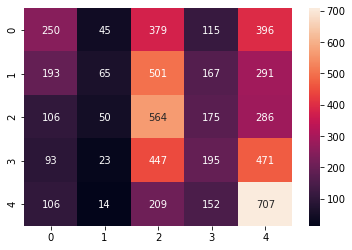

```python
import seaborn as sns
sns.heatmap(cm, annot=True, fmt="d")
```

```python
test[(test['Score']==4) & (test['predictions']==5)]['Text'].reset_index().iloc[3].Text
```

```
'This Boston Cream Pie flavored coffee from Donut Shop Classics wasn\'t anything special. In fact, the name Boston Cream Pie might just be a fancy way of saying "here is your standard fare of coffee with rich cream". It was smooth, rich, and delicious, just as I expect Donut Shop Classics coffee to …
```

```python
test[(test['Score']==5) & (test['predictions']==4)]['Text'].reset_index().iloc[4].Text
```

```
'Just an outstanding product<br /><br />An authentic dulce de leche ranked number-one in Argentina for its exceptional richness and depth of flavor.<br /><br />Made at a small dairy outside of Buenos Aires.<br /><br />(note that the web page or supplier indicates "Made in Spain" but this product is …
```

```python
test[(test['Score']==1) & (test['predictions']==2)]['Text'].reset_index().iloc[1].Text
```

```
"...I will drink this if all other coffee options are exhausted. The coffee has a vanilla/coconut smell but after a sip or two, I can't drink it. Would not purchase again and I'm having trouble even giving it away. I expected more from Wolfgang Puck."
```

```python
test[(test['Score']==2) & (test['predictions']==1)]['Text'].reset_index().iloc[3].Text
```

```
"I started feeding my chocolate lab his dinner in this toy and it worked well.  I really enjoyed watching him figure out how to dump this kibble out and he seemed to enjoying the challenge of getting every last piece out.  He took to picking up the empty jug and dropping it, as if to ask for more fo…
```

This is great, and what we would expect. Some reviewers may be "harsher" than others, and the difference between a 4- and 5-star review is often more down to individual differences than the content of the review itself, so we can't really expect our network to always be able to predict the difference between these.

Given this, it would be good to go back and assign a smaller penalty for the model misclassifying 4- vs. 5-star ratings, and 1- vs. 2-star ratings, since these differences are not nearly so important. That way, the model's parameters can be tuned to optimize for differentiating between reviews which are at least reasonably far from each other on the satisfaction scale. We could also break the model into two parts - one to classify a review as good, neutral, or bad, and a second, sequential piece to then break down the good reviews into 4- and 5-star classifications, and bad reviews into 1- and 2-star classifications.

Hopefully, you have seen from this that there is no one-size-fits-all method when creating model architectures or tuning parameters. Often times, copious experimentation is needed, and even then it can be difficult to get significantly better results than a baseline model or even really diagnose what is going wrong under the hood (since neural networks are so "black-box"). In many cases, the quantity and quality of the data itself is far more important than the architecture of the network for getting good results.